# Principal Component Analysis

## Unsupervised Learning Recap

- So far we’ve covered two unsupervised learning methods:
  - **K-means clustering**: partition data into K groups
  - **Hierarchical clustering**: create a dendrogram showing case similarity
- Both methods group *cases* based on their X-variable values
- Today: **Principal Component Analysis (PCA)**
  - transforms and reduces the *variables* themselves
  - finds the most important directions of variation in the data

## The Dimensionality Problem

- Modern datasets often have many variables (high-dimensional)
  - Customer data: age, income, spending across 100+ product categories
  - Gene expression: measurements on 10,000+ genes
  - Image data: thousands of pixel values
- Problems with high dimensions:
  - Difficult to visualize
  - Models become computationally expensive
  - More susceptible to overfitting
- Solution: reduce dimensions while retaining most information

## What is Principal Component Analysis?

- PCA finds new variables (principal components) that are:
  - **linear combinations** of the original variables
  - **uncorrelated** with each other
  - ordered by how much **variation** they explain
- The first principal component (PC1) explains the most variation
- The second principal component (PC2) explains the second most variation
- And so on…
- We typically use only the first few PCs (dimension reduction!)

## Simple 2D Example

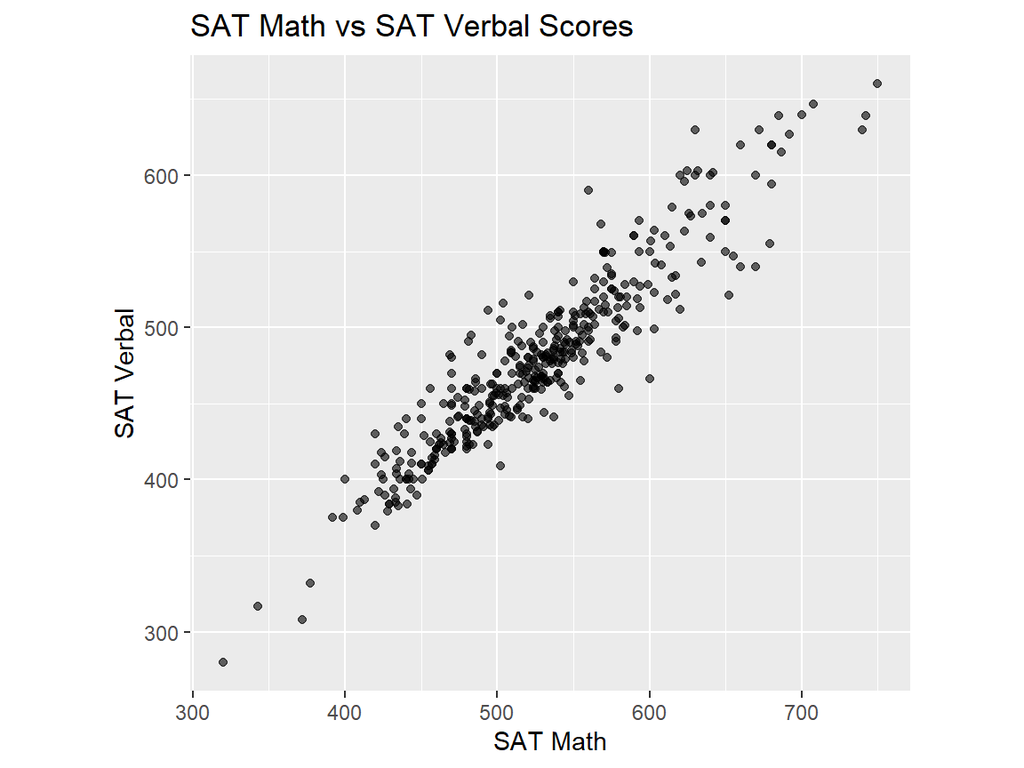

- Notice: SAT Math and Verbal scores are positively correlated
- Can we capture this pattern with a single new variable?

## Principal Component 1 (PC1)

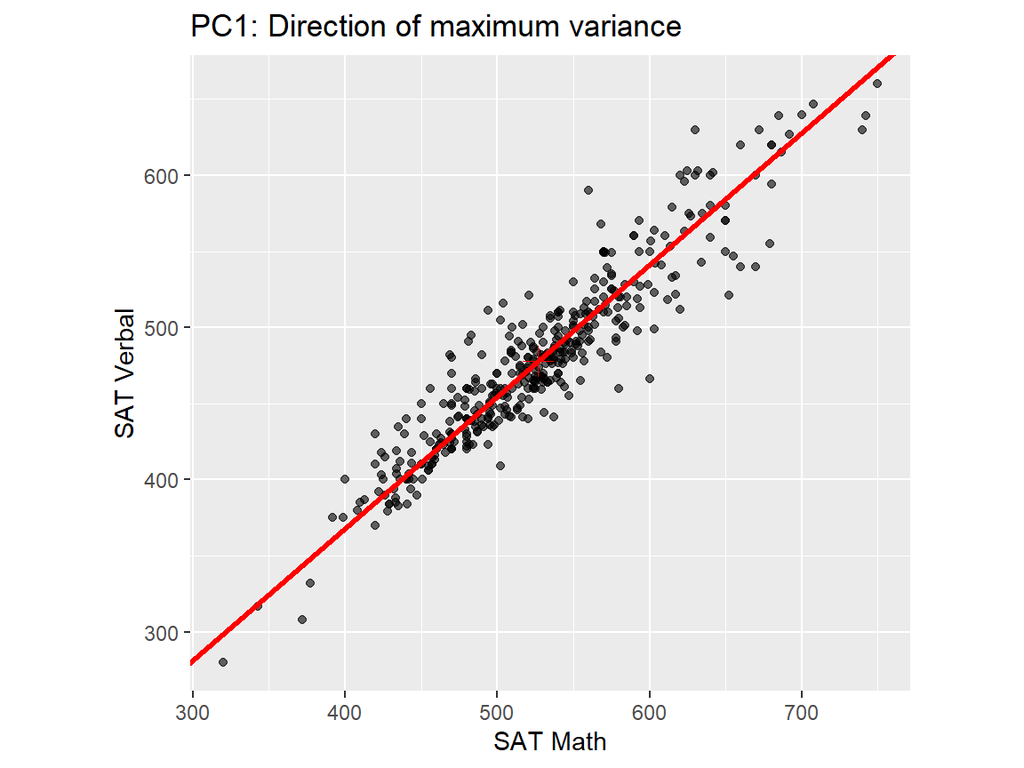

- PC1 is the line that captures the most variation in the data
- It’s the direction along which the data varies the most
- **Interpretation**: PC1 is roughly like an “overall SAT score” (≈ average of Math and Verbal)

## Principal Component 2 (PC2)

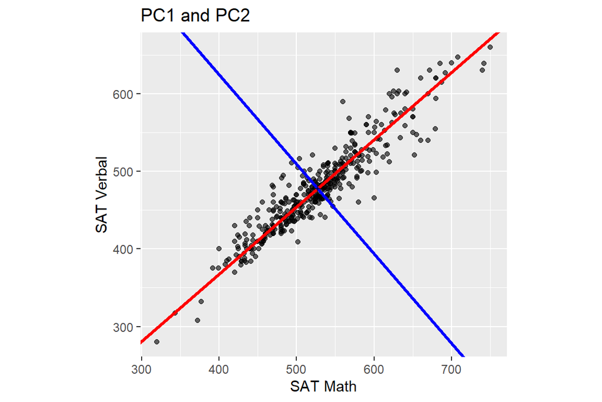

- PC2 is perpendicular (orthogonal) to PC1
- It captures the remaining variation not explained by PC1
- PC1 and PC2 are **uncorrelated**
- **Interpretation**: PC2 is roughly like the “difference” between Math and Verbal

## PCA as Dimension Reduction

- Original data: 2 dimensions (SATM, SATV)
- After PCA: 2 principal components (PC1, PC2)
- **Key insight**: If variables are correlated, most information is in PC1
  - We can often drop PC2 with little loss of information
  - Result: 2D → 1D dimension reduction!
- With \(p\) variables, we often use just the first 2-3 PCs
  - Makes visualization possible
  - Speeds up downstream analyses (clustering, modeling)

## Mathematical Definition

- For a dataset with p variables: \(X_1, X_2, ..., X_p\)
- The first principal component is: \[ Z_1 = \phi_{11}X_1 + \phi_{21}X_2 + ... + \phi_{p1}X_p \]
- Where \(\phi_1 = (\phi_{11}, \phi_{21},...,\phi_{p1})^T\) is the **loading vector**
- Constraint: \(\sum_{j=1}^p \phi_{j1}^2 = 1\) (unit length)
- \(\phi_1\) is chosen to maximize the variance of \(Z_1\)

## Subsequent Principal Components

- The second principal component \(Z_2\) is also a linear combination: \[ Z_2 = \phi_{12}X_1 + \phi_{22}X_2 + ... + \phi_{p2}X_p \]
- Constraints:
  - Uncorrelated with \(Z_1\) (perpendicular loading vectors)
  - Maximizes variance subject to being uncorrelated with \(Z_1\)
- This process continues for all p components
- In practice: we use only the first M components (M << p)

## Proportion of Variance Explained

- Each PC explains a certain percentage of total variation
- **Proportion of Variance Explained (PVE)** by PC m: \[ \text{PVE}_m = \frac{\text{Var}(Z_m)}{\sum_{k=1}^p \text{Var}(Z_k)} \]
- Total PVE by first M components: \[ \sum_{m=1}^M \text{PVE}_m \]
- Typically want first few PCs to explain 70-90% of variation

## Important Notes on PCA

- **Always standardize your variables!**
  - PCA is sensitive to the scale of variables
  - Use `scale=TRUE` in R’s `prcomp()` function
- PCA is an **unsupervised** method
  - Does not use response variable y
  - Components are chosen to explain X variation, not y variation
- PCA is useful for:
  - Data visualization (plot first 2-3 PCs)
  - Reducing computational burden
  - Addressing multicollinearity in regression

## PCA in R: `prcomp()` function

- Base R function: `prcomp(x, center, scale)`
  - `x`: matrix or data frame of numeric variables
  - `center`: should variables be centered? (default TRUE)
  - `scale`: should variables be standardized? (recommended TRUE)
- Output: `pca_out <- prcomp(...)`
  - `pca_out$x`: the principal component scores (values of \(Z_1, Z_2, ...\))
  - `pca_out$rotation`: the loading vectors (\(\phi\) values)
  - `pca_out$sdev`: standard deviation of each PC
  - Use `summary(pca_out)` to see proportion of variance explained

## Example: CA and MA Colleges

- Let’s use the same dataset from Day 20 Activity
- Multiple variables capture different aspects of colleges

```r
> head(college_data)
# A tibble: 6 × 10
  College   State avg_sat adm_rate HStop10  cost Ratio Donate AvgSalary FullTime
  <chr>     <chr>   <dbl>    <dbl>   <dbl> <dbl> <dbl>  <dbl>     <dbl>    <dbl>
1 Californ… CA       705     0.265      98 22481   6.5     36       866      912
2 Californ… CA       466.    0.439      23 18862  12.4     17       398     1427
3 Californ… CA       501     0.489      47  7522  19.8     13       571    12911
4 Chapman … CA       478.    0.804      23 23119  12.8      6       491     1662
5 Claremon… CA       635     0.412      71 23510   9.6     52       601      887
6 Harvey M… CA       685     0.415      95 24620   8.2     46       638      654
```

## Example: The Variables

- **8 numeric variables** capturing different college characteristics:
  - `avg_sat`: Average SAT score
  - `adm_rate`: Admission rate (lower = more selective)
  - `HStop10`: % of students from top 10% of HS class
  - `cost`: Total annual cost (tuition + room + board + books)
  - `Ratio`: Student-faculty ratio
  - `Donate`: % of alumni who donate
  - `AvgSalary`: Average alumni salary
  - `FullTime`: Number of full-time students
- Can’t visualize 8 dimensions! Perfect for PCA

## Example: How Variables Relate

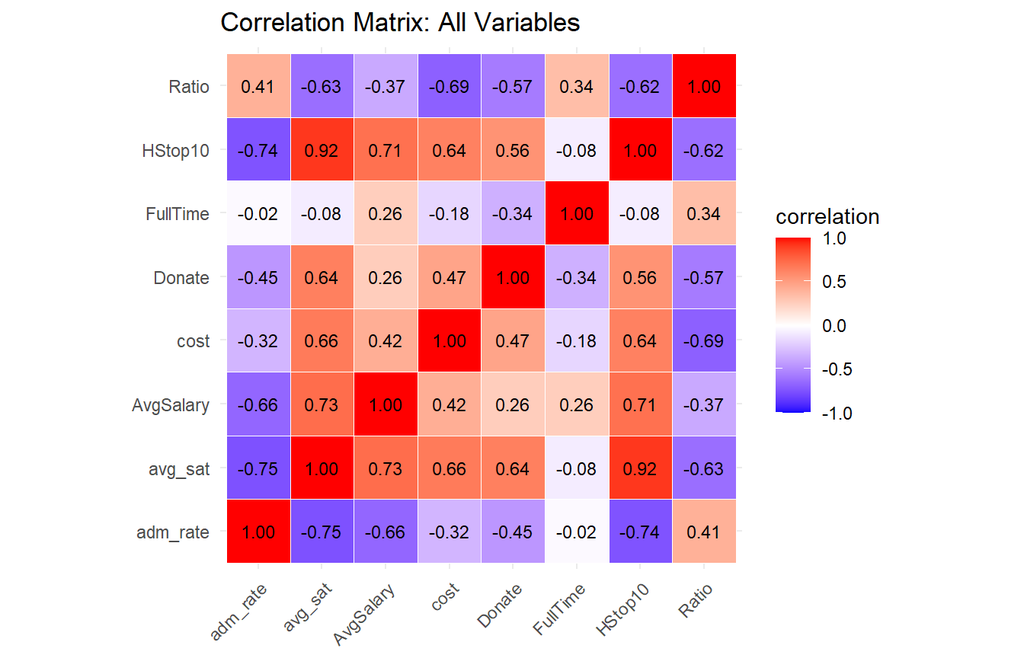

- Many variables are correlated (red = positive, blue = negative)
- SAT scores negatively correlated with admission rate (lower rate = more selective)
- Can we capture these patterns in fewer dimensions?

## Example: Run PCA

```r
> pca_colleges <- prcomp(cluster_vars, scale=TRUE)
> names(pca_colleges)
[1] "sdev"     "rotation" "center"   "scale"    "x"
```

- Using all 8 numeric variables
- `scale=TRUE` standardizes each variable to mean 0, variance 1

## Example: Loadings (rotation)

```r
> pca_colleges$rotation[,1:2]  # Show first 2 PCs
                 PC1         PC2
avg_sat   -0.4464004  0.08545209
adm_rate   0.3607750 -0.26055789
HStop10   -0.4354914  0.10555326
cost      -0.3491074 -0.18132558
Ratio      0.3586252  0.30788231
Donate    -0.3293211 -0.31018695
AvgSalary -0.3410182  0.44205717
FullTime   0.0753766  0.70311099
```

**Note**: PCA signs are arbitrary: all signs can be flipped without changing the analysis

**PC1**:

- **high** avg_sat, HStop10, cost, AvgSalary, Donate and **low** adm_rate, Ratio, FullTime
- Interpretation: **“prestige/selectivity”** dimension

**PC2**:

- **high** FullTime, AvgSalary, Ratio and **low** cost, adm_rate, donate
- Interpretation: **school size** once you’ve accounted for **prestige**
  - For example: MIT and HMC have similar prestige but different size

## Example: Variance Explained

```r
> summary(pca_colleges)
Importance of components:
                          PC1    PC2     PC3     PC4     PC5     PC6     PC7
Standard deviation     2.1374 1.2221 0.83390 0.67400 0.54912 0.49916 0.41118
Proportion of Variance 0.5711 0.1867 0.08692 0.05678 0.03769 0.03114 0.02113
Cumulative Proportion  0.5711 0.7577 0.84466 0.90145 0.93914 0.97028 0.99142
                           PC8
Standard deviation     0.26205
Proportion of Variance 0.00858
Cumulative Proportion  1.00000
```

- PC1 explains 57% of total variance
- PC2 explains an additional 19%
- First 2 PCs capture 76% of variation
- **Key insight**: Can reduce from 8D to 2D and keep most information!

## Example: Scree Plot

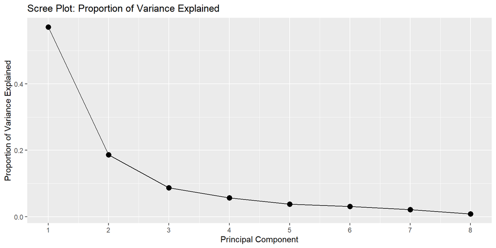

- Clear “elbow” after PC2 or PC3
- First 2-3 PCs capture the main patterns

## Example: Biplot Visualization

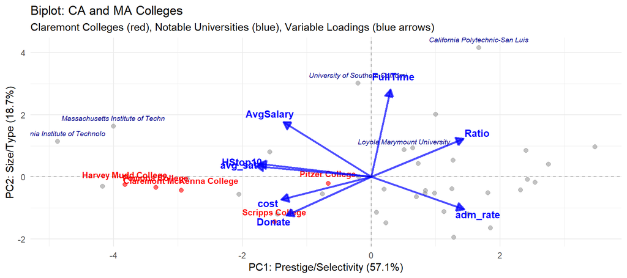

- **Points**: Each dot is a college (red = Claremont, gray = others)
- **Blue arrows**: Show how original variables contribute to PC1 and PC2
- Arrows pointing right = high positive loading on PC1
- Arrows pointing up = high positive loading on PC2

## Dimension Reduction in Action

- Original data: 8 dimensions (avg_sat, adm_rate, HStop10, cost, Ratio, Donate, AvgSalary, FullTime)
- After PCA: Can use just first 2 PCs with acceptable information loss
- First 2 PCs capture 76% of variation!
- This is dimension reduction:
  - 8D → 2D
  - Loses 24% of information but gains simplicity
  - Makes visualization possible!
  - Can now see college relationships on a 2D plot

## Comparing with Day 20 Clustering

- On Day 20, we used hierarchical clustering on these same colleges
- Now let’s use k-means on PC scores (which capture all 8 variables!)
- Using first 2 PCs since they explain 70-75% of variance
- Using K=4 to get nuanced groupings

## Example: Visualizing Clusters on PC Scores

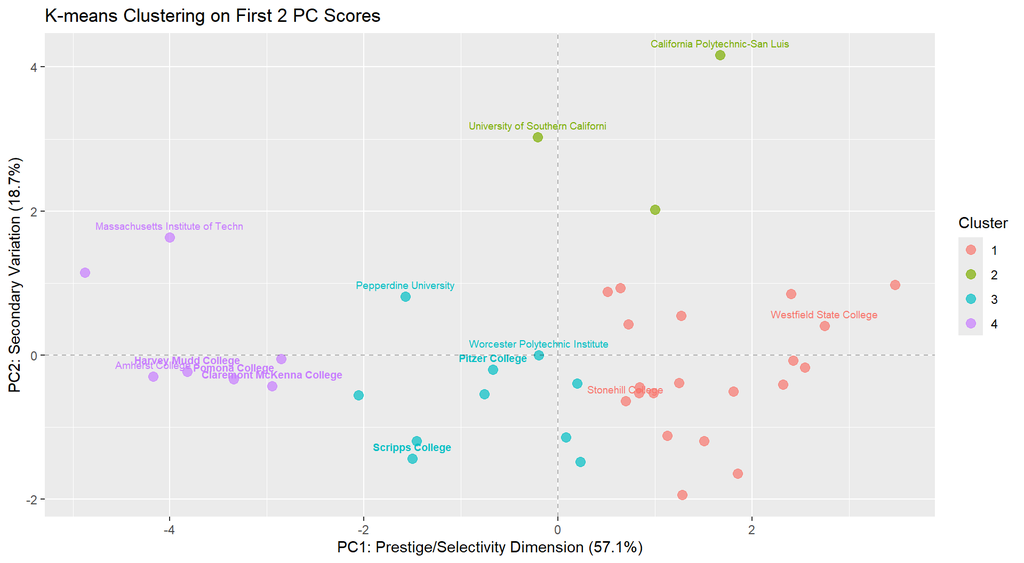

## Cluster Interpretation

- Look at the plot above to see where clusters fall on the PC1-PC2 space
- **Labeled colleges**: Claremont Colleges (bold) + 2 random colleges from each cluster
- **Most selective cluster**: Contains the most elite schools from CA and MA
  - Highest selectivity, SAT scores, costs, alumni outcomes
  - Will cluster together regardless of which side of the plot
- **Selective liberal arts cluster**: Very selective smaller schools
  - May differ from top cluster on PC2 (size, specific characteristics)
- **Regional universities**: Moderately selective schools
  - Good schools that are more accessible
- **Less selective/larger schools**: Higher admission rates, more accessible

## When to Use PCA

- **Use PCA when:**
  - You have many correlated variables
  - You want to visualize high-dimensional data
  - You need to speed up computation
  - You want to address multicollinearity
- **Be cautious when:**
  - Variables are already uncorrelated (PCA won’t help much)
  - You need to interpret individual variables (PCs are combinations)
  - You have categorical variables (PCA requires numeric data)

## Summary

- **PCA** transforms correlated variables into uncorrelated principal components
- Components are ordered by variance explained
- **How to interpret PCs**:
  - Look at loadings: which original variables have large weights?
  - PC1 captures the main pattern
  - PC2 captures the second pattern
  - Later PCs capture progressively smaller patterns
- Use **scree plots** to decide how many PCs to retain
- **Always standardize** variables before PCA